# Python "pandas" kütüphanesine giriş

- CSV dosyası okuma

```python
# 2017 dünya mutluluk raporu
whp_2017 = pd.read_csv("world_happiness_report_2017.csv")
whp_2017.head()
```

|  | Country | Happiness.Rank | Happiness.Score | Whisker.high | Whisker.low | Economy..GDP.per.Capita. | Family | Health..Life.Expectancy. | Freedom | Generosity | Trust..Government.Corruption. | Dystopia.Residual |
| --- | --- | --- | --- | --- | --- | --- | --- | --- | --- | --- | --- | --- |
| 0 | Norway | 1 | 7.537 | 7.594445 | 7.479556 | 1.616463 | 1.533524 | 0.796667 | 0.635423 | 0.362012 | 0.315964 | 2.277027 |
| 1 | Denmark | 2 | 7.522 | 7.581728 | 7.462272 | 1.482383 | 1.551122 | 0.792566 | 0.626007 | 0.355280 | 0.400770 | 2.313707 |
| 2 | Iceland | 3 | 7.504 | 7.622030 | 7.385970 | 1.480633 | 1.610574 | 0.833552 | 0.627163 | 0.475540 | 0.153527 | 2.322715 |
| 3 | Switzerland | 4 | 7.494 | 7.561772 | 7.426227 | 1.564980 | 1.516912 | 0.858131 | 0.620071 | 0.290549 | 0.367007 | 2.276716 |
| 4 | Finland | 5 | 7.469 | 7.527542 | 7.410458 | 1.443572 | 1.540247 | 0.809158 | 0.617951 | 0.245483 | 0.382612 | 2.430182 |

```python
whp_2017.info()
```

```
<class 'pandas.core.frame.DataFrame'>
RangeIndex: 155 entries, 0 to 154
Data columns (total 12 columns):
Country                          155 non-null object
Happiness.Rank                   155 non-null int64
Happiness.Score                  155 non-null float64
Whisker.high                     155 non-null float64
Whisker.low                      155 non-null float64
Economy..GDP.per.Capita.         155 non-null float64
Family                           155 non-null float64
Health..Life.Expectancy.         155 non-null float64
Freedom                          155 non-null float64
Generosity                       155 non-null float64
Trust..Government.Corruption.    155 non-null float64
Dystopia.Residual                155 non-null float64
dtypes: float64(10), int64(1), object(1)
memory usage: 14.6+ KB
```

```python
whp_2017.describe()
```

|  | Happiness.Rank | Happiness.Score | Whisker.high | Whisker.low | Economy..GDP.per.Capita. | Family | Health..Life.Expectancy. | Freedom | Generosity | Trust..Government.Corruption. | Dystopia.Residual |
| --- | --- | --- | --- | --- | --- | --- | --- | --- | --- | --- | --- |
| count | 155.000000 | 155.000000 | 155.000000 | 155.000000 | 155.000000 | 155.000000 | 155.000000 | 155.000000 | 155.000000 | 155.000000 | 155.000000 |
| mean | 78.000000 | 5.354019 | 5.452326 | 5.255713 | 0.984718 | 1.188898 | 0.551341 | 0.408786 | 0.246883 | 0.123120 | 1.850238 |
| std | 44.888751 | 1.131230 | 1.118542 | 1.145030 | 0.420793 | 0.287263 | 0.237073 | 0.149997 | 0.134780 | 0.101661 | 0.500028 |
| min | 1.000000 | 2.693000 | 2.864884 | 2.521116 | 0.000000 | 0.000000 | 0.000000 | 0.000000 | 0.000000 | 0.000000 | 0.377914 |
| 25% | 39.500000 | 4.505500 | 4.608172 | 4.374955 | 0.663371 | 1.042635 | 0.369866 | 0.303677 | 0.154106 | 0.057271 | 1.591291 |
| 50% | 78.000000 | 5.279000 | 5.370032 | 5.193152 | 1.064578 | 1.253918 | 0.606042 | 0.437454 | 0.231538 | 0.089848 | 1.832910 |
| 75% | 116.500000 | 6.101500 | 6.194600 | 6.006527 | 1.318027 | 1.414316 | 0.723008 | 0.516561 | 0.323762 | 0.153296 | 2.144654 |
| max | 155.000000 | 7.537000 | 7.622030 | 7.479556 | 1.870766 | 1.610574 | 0.949492 | 0.658249 | 0.838075 | 0.464308 | 3.117485 |

- JSON okuma

```python
hs_cards = pd.read_json("hs_cards.json")
hs_cards.head()
```

|  | artist | attack | classes | collectible | collectionText | cost | dbfId | durability | dust | entourage | ... | overload | playRequirements | playerClass | race | rarity | set | spellDamage | targetingArrowText | text | type |
| --- | --- | --- | --- | --- | --- | --- | --- | --- | --- | --- | --- | --- | --- | --- | --- | --- | --- | --- | --- | --- | --- |
| 0 | NaN | NaN | NaN | NaN | NaN | 1.0 | 39762.0 | NaN | NaN | NaN | ... | NaN | {'REQ_NUM_MINION_SLOTS': 1} | MAGE | NaN | NaN | KARA | NaN | NaN | Summon a random <b>Legendary</b> minion. | SPELL |
| 1 | NaN | NaN | NaN | NaN | NaN | 0.0 | 313.0 | NaN | NaN | NaN | ... | NaN | NaN | DRUID | NaN | NaN | EXPERT1 | NaN | NaN | Draw a card. | SPELL |
| 2 | Hideaki Takamura | 2.0 | NaN | NaN | NaN | 3.0 | 2311.0 | NaN | [40, 400, 5, 50] | NaN | ... | NaN | NaN | DRUID | BEAST | COMMON | BRM | NaN | NaN | NaN | MINION |
| 3 | Jomaro Kindred | 6.0 | NaN | 1.0 | NaN | 6.0 | 2736.0 | NaN | [1600, 3200, 400, 1600] | NaN | ... | NaN | NaN | NEUTRAL | NaN | LEGENDARY | TGT | NaN | NaN | <b>Battlecry:</b> Replace your starting Hero P... | MINION |
| 4 | Zoltan Boros | 10.0 | NaN | 1.0 | NaN | 10.0 | 38521.0 | NaN | [40, 400, 5, 50] | NaN | ... | NaN | NaN | NEUTRAL | NaN | COMMON | OG | NaN | NaN | NaN | MINION |

5 rows × 29 columns

**DataFrame indeksleme**

- Bir sütunu seçme

```python
whp_2017["Country"].head() # çıktıyı kısaltmak için head() kullanalım
```

```
0         Norway
1        Denmark
2        Iceland
3    Switzerland
4        Finland
Name: Country, dtype: object
```

```python
# Veya
whp_2017.Country.head()
```

```
0         Norway
1        Denmark
2        Iceland
3    Switzerland
4        Finland
Name: Country, dtype: object
```

- Birden fazla sütun seçme

```python
whp_2017[["Country","Happiness.Score"]].head()
```

|  | Country | Happiness.Score |
| --- | --- | --- |
| 0 | Norway | 7.537 |
| 1 | Denmark | 7.522 |
| 2 | Iceland | 7.504 |
| 3 | Switzerland | 7.494 |
| 4 | Finland | 7.469 |

- Satırları kesme

```python
whp_2017[0:3]
```

|  | Country | Happiness.Rank | Happiness.Score | Whisker.high | Whisker.low | Economy..GDP.per.Capita. | Family | Health..Life.Expectancy. | Freedom | Generosity | Trust..Government.Corruption. | Dystopia.Residual |
| --- | --- | --- | --- | --- | --- | --- | --- | --- | --- | --- | --- | --- |
| 0 | Norway | 1 | 7.537 | 7.594445 | 7.479556 | 1.616463 | 1.533524 | 0.796667 | 0.635423 | 0.362012 | 0.315964 | 2.277027 |
| 1 | Denmark | 2 | 7.522 | 7.581728 | 7.462272 | 1.482383 | 1.551122 | 0.792566 | 0.626007 | 0.355280 | 0.400770 | 2.313707 |
| 2 | Iceland | 3 | 7.504 | 7.622030 | 7.385970 | 1.480633 | 1.610574 | 0.833552 | 0.627163 | 0.475540 | 0.153527 | 2.322715 |

- Seçim için "loc" kullanımı
  - "loc" satırları (veya sütunları) seçmek için indeksteki belirli etiketleri kullanır

```python
whp_2017.loc[[1,2,3],["Country","Happiness.Rank"]]
```

|  | Country | Happiness.Rank |
| --- | --- | --- |
| 1 | Denmark | 2 |
| 2 | Iceland | 3 |
| 3 | Switzerland | 4 |

- Seçim için "iloc" kullanımı
  - "iloc" sütun (veya satırların) indeksteki konumlarını kullanır

```python
whp_2017.iloc[1:3,0:2]
```

|  | Country | Happiness.Rank |
| --- | --- | --- |
| 1 | Denmark | 2 |
| 2 | Iceland | 3 |

Yukarıdaki örnekte "loc" fonksiyonun etiket aldığına iloc fonksiyonunun tamsayı aldığına dikkat ediniz

loc ve iloc hakkında daha fazla bilgi almak için aşağıdaki bağlantıya bakmanızı tavsiye ederim. https://stackoverflow.com/questions/31593201/pandas-iloc-vs-ix-vs-loc-explanation-how-are-they-different

**DataFrame Operasyonları**

- Mantıksal seçim
  - Çoklu operasyonlar için &, | operatörleri kullanılmalıdır.

```python
# Mutluluk değeri 5.5 üzeri ve 5.7 altı olan ülkelerin seçimi
whp_2017[ (whp_2017["Happiness.Score"]>5.5) & (whp_2017["Happiness.Score"]<5.7)]
```

|  | Country | Happiness.Rank | Happiness.Score | Whisker.high | Whisker.low | Economy..GDP.per.Capita. | Family | Health..Life.Expectancy. | Freedom | Generosity | Trust..Government.Corruption. | Dystopia.Residual |
| --- | --- | --- | --- | --- | --- | --- | --- | --- | --- | --- | --- | --- |
| 63 | Mauritius | 64 | 5.629 | 5.729862 | 5.528138 | 1.189396 | 1.209561 | 0.638007 | 0.491247 | 0.360934 | 0.042182 | 1.697584 |
| 64 | Cyprus | 65 | 5.621 | 5.714693 | 5.527307 | 1.355938 | 1.131363 | 0.844715 | 0.355112 | 0.271254 | 0.041238 | 1.621249 |
| 65 | Estonia | 66 | 5.611 | 5.688140 | 5.533860 | 1.320879 | 1.476671 | 0.695168 | 0.479131 | 0.098891 | 0.183249 | 1.357509 |
| 66 | Belarus | 67 | 5.569 | 5.646114 | 5.491885 | 1.156558 | 1.444945 | 0.637714 | 0.295400 | 0.155138 | 0.156314 | 1.723233 |
| 67 | Libya | 68 | 5.525 | 5.676954 | 5.373046 | 1.101803 | 1.357564 | 0.520169 | 0.465733 | 0.152074 | 0.092610 | 1.835011 |

- Satıraları düşürmek
  - Bu operasyon dataframe'i değiştirmez. Eğer dataframe'i değiştirmek istiyorsanız *inplace=True* kullanın

```python
# İlk iki tane hariç tüm satırları düşürelim
whp_2017.drop(range(2,whp_2017.shape[0]))
```

|  | Country | Happiness.Rank | Happiness.Score | Whisker.high | Whisker.low | Economy..GDP.per.Capita. | Family | Health..Life.Expectancy. | Freedom | Generosity | Trust..Government.Corruption. | Dystopia.Residual |
| --- | --- | --- | --- | --- | --- | --- | --- | --- | --- | --- | --- | --- |
| 0 | Norway | 1 | 7.537 | 7.594445 | 7.479556 | 1.616463 | 1.533524 | 0.796667 | 0.635423 | 0.362012 | 0.315964 | 2.277027 |
| 1 | Denmark | 2 | 7.522 | 7.581728 | 7.462272 | 1.482383 | 1.551122 | 0.792566 | 0.626007 | 0.355280 | 0.400770 | 2.313707 |

- Sütunları düşürmek
  - *axis=1* parametresinin eklenmesi gerekir

```python
whp_2017.drop("Country",axis=1).head()
```

|  | Happiness.Rank | Happiness.Score | Whisker.high | Whisker.low | Economy..GDP.per.Capita. | Family | Health..Life.Expectancy. | Freedom | Generosity | Trust..Government.Corruption. | Dystopia.Residual |
| --- | --- | --- | --- | --- | --- | --- | --- | --- | --- | --- | --- |
| 0 | 1 | 7.537 | 7.594445 | 7.479556 | 1.616463 | 1.533524 | 0.796667 | 0.635423 | 0.362012 | 0.315964 | 2.277027 |
| 1 | 2 | 7.522 | 7.581728 | 7.462272 | 1.482383 | 1.551122 | 0.792566 | 0.626007 | 0.355280 | 0.400770 | 2.313707 |
| 2 | 3 | 7.504 | 7.622030 | 7.385970 | 1.480633 | 1.610574 | 0.833552 | 0.627163 | 0.475540 | 0.153527 | 2.322715 |
| 3 | 4 | 7.494 | 7.561772 | 7.426227 | 1.564980 | 1.516912 | 0.858131 | 0.620071 | 0.290549 | 0.367007 | 2.276716 |
| 4 | 5 | 7.469 | 7.527542 | 7.410458 | 1.443572 | 1.540247 | 0.809158 | 0.617951 | 0.245483 | 0.382612 | 2.430182 |

- Bir sütunu baz alarak sıralamak için
  - *ascending=False* yaparsanız en yüksek değerler en önce görünür

```python
whp_2017.sort_values(by="Economy..GDP.per.Capita.",ascending=False).head()
```

|  | Country | Happiness.Rank | Happiness.Score | Whisker.high | Whisker.low | Economy..GDP.per.Capita. | Family | Health..Life.Expectancy. | Freedom | Generosity | Trust..Government.Corruption. | Dystopia.Residual |
| --- | --- | --- | --- | --- | --- | --- | --- | --- | --- | --- | --- | --- |
| 34 | Qatar | 35 | 6.375 | 6.568477 | 6.181523 | 1.870766 | 1.274297 | 0.710098 | 0.604131 | 0.330474 | 0.439299 | 1.145464 |
| 17 | Luxembourg | 18 | 6.863 | 6.923686 | 6.802314 | 1.741944 | 1.457584 | 0.845089 | 0.596628 | 0.283181 | 0.318834 | 1.619512 |
| 25 | Singapore | 26 | 6.572 | 6.636723 | 6.507277 | 1.692278 | 1.353814 | 0.949492 | 0.549841 | 0.345966 | 0.464308 | 1.216362 |
| 38 | Kuwait | 39 | 6.105 | 6.191957 | 6.018043 | 1.632952 | 1.259699 | 0.632106 | 0.496338 | 0.228290 | 0.215160 | 1.640425 |
| 20 | United Arab Emirates | 21 | 6.648 | 6.722047 | 6.573952 | 1.626343 | 1.266410 | 0.726798 | 0.608345 | 0.360942 | 0.324490 | 1.734704 |

- Kullanması en zevkli fonksiyonlardan biri rank()'tir bana göre
  - Her elemanın sütundaki pozisyonunu döndürür. Aşağıdaki örnek söylediklerimi daha iyi açıklayacaktır.

```python
whp_2017.rank().head()
```

|  | Country | Happiness.Rank | Happiness.Score | Whisker.high | Whisker.low | Economy..GDP.per.Capita. | Family | Health..Life.Expectancy. | Freedom | Generosity | Trust..Government.Corruption. | Dystopia.Residual |
| --- | --- | --- | --- | --- | --- | --- | --- | --- | --- | --- | --- | --- |
| 0 | 105.0 | 1.0 | 155.0 | 154.0 | 155.0 | 150.0 | 149.0 | 128.0 | 154.0 | 130.0 | 145.0 | 127.0 |
| 1 | 38.0 | 2.0 | 154.0 | 153.0 | 154.0 | 138.0 | 153.0 | 125.0 | 151.0 | 127.0 | 152.0 | 131.0 |
| 2 | 58.0 | 3.0 | 153.0 | 155.0 | 151.0 | 137.0 | 155.0 | 141.0 | 152.0 | 145.0 | 117.0 | 132.0 |
| 3 | 133.0 | 4.0 | 152.0 | 152.0 | 153.0 | 149.0 | 147.0 | 150.0 | 150.0 | 107.0 | 148.0 | 126.0 |
| 4 | 45.0 | 5.0 | 151.0 | 151.0 | 152.0 | 134.0 | 150.0 | 131.0 | 149.0 | 85.0 | 149.0 | 136.0 |

- Eğer iki seriyi toplarsak ne olur?
  - Aşağıdaki örnekte göreceğiniz üzere çakışan indekslerdeki veriler toplanır, diğer indeksler için NaN değerleri oluşturulur.

```python
age_pd_series = pd.Series({"A":33,"B":24,"C":45,"E":18},name="yaş")
weight_pd_series = pd.Series({"A":55,"B":65,"C":75,"D":80},name="kilo") # in kg :)

age_pd_series + weight_pd_series
```

```
A     88.0
B     89.0
C    120.0
D      NaN
E      NaN
dtype: float64
```

**Pandas ile temel grafik çizimi**

Pandas kütüphanesi "matplotlib" tabanlı çizdirme fonksiyonlarına sahiptir. Bunlar için hızlı bir gösterim yapalım

```python
# Varsayılan plot grafiği
whp_2017.Generosity.plot();
```

[output not shown]

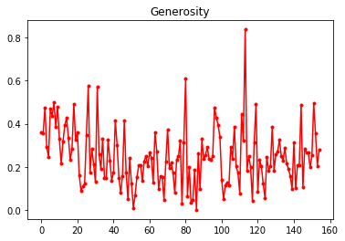

```python
# Grafikler için stil ekleyebiliriz
whp_2017.Generosity.plot(style="r.-",title="Generosity");
```

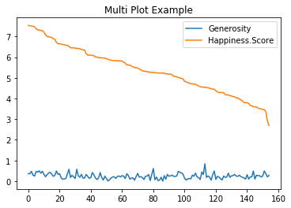

```python
# Çoklu grafik
whp_2017[["Generosity","Happiness.Score"]].plot(title="Multi Plot Example");
```

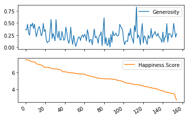

```python
# Alt grafiklerden oluşan çoklu grafik
whp_2017[["Generosity","Happiness.Score"]].plot(subplots=True);
```

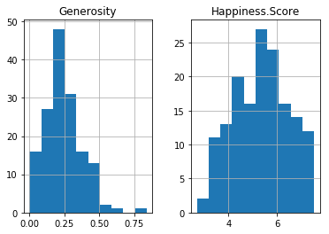

```python
# Histogram
whp_2017[["Generosity","Happiness.Score"]].hist();
```

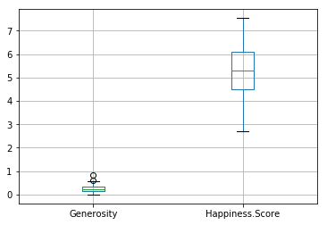

```python
# Boxplot'lar
whp_2017[["Generosity","Happiness.Score"]].boxplot();
```